# Project2

Hana Kysela

May 21, 2016

# Project 2 - ToothGrow data analysis

## Overview

The response is the length of odontoblasts (cells responsible for tooth growth) in 60 guinea pigs. Each animal received one of three dose levels of vitamin C (0.5, 1, and 2 mg/day) by one of two delivery methods, (orange juice or ascorbic acid (a form of vitamin C and coded as VC). Source: https://stat.ethz.ch/R-manual/R-devel/library/datasets/html/ToothGrowth.html

Load the ToothGrowth data and perform some basic exploratory data analyses Provide a basic summary of the data. Use confidence intervals and/or hypothesis tests to compare tooth growth by supp and dose. State your conclusions and the assumptions needed for your conclusions.

```r
# packages management
if (!require("pacman")) install.packages("pacman")
  pacman::p_load(ggplot2, datasets)
```

## 1. Load the data + 2. Provide basic summary of the data

```r
data("ToothGrowth")
ToothGrowth$dose<-as.factor(ToothGrowth$dose)
str(ToothGrowth) #shows data types
```

```
## 'data.frame':    60 obs. of  3 variables:
##  $ len : num  4.2 11.5 7.3 5.8 6.4 10 11.2 11.2 5.2 7 ...
##  $ supp: Factor w/ 2 levels "OJ","VC": 2 2 2 2 2 2 2 2 2 2 ...
##  $ dose: Factor w/ 3 levels "0.5","1","2": 1 1 1 1 1 1 1 1 1 1 ...
```

```r
summary(ToothGrowth) #shows summary of values
```

```
##       len        supp     dose
##  Min.   : 4.20   OJ:30   0.5:20
##  1st Qu.:13.07   VC:30   1  :20
##  Median :19.25           2  :20
##  Mean   :18.81
##  3rd Qu.:25.27
##  Max.   :33.90
```

## Growth analysis:

A. Will higher dosage of supplements result in bigger lenght of odontoblasts?

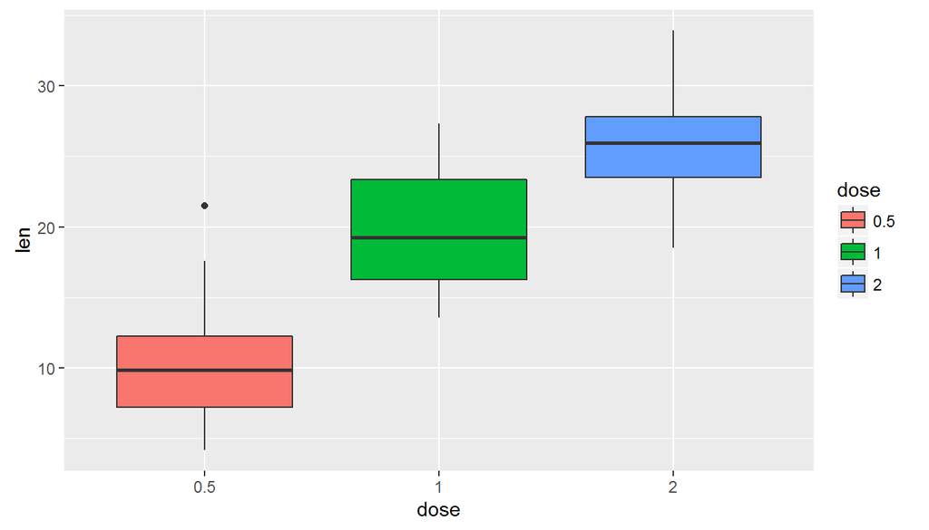

```r
  ggplot(data=ToothGrowth, aes(x=dose,y=len,fill=dose)) +
  geom_boxplot()
```

B. Does the supplement type matter?

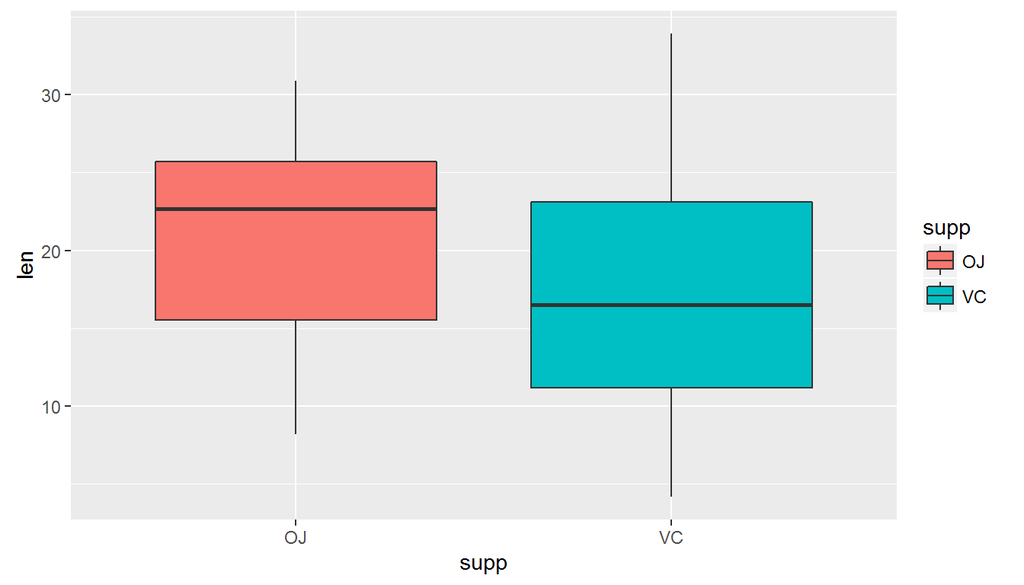

```r
  ggplot(data=ToothGrowth, aes(x=supp,y=len,fill=supp)) +
  geom_boxplot()
```

C. Or is it combination of both?

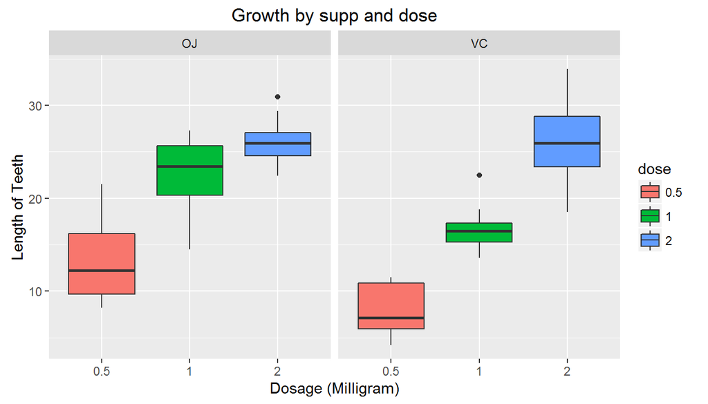

```r
ggplot(ToothGrowth, aes(x=dose,y=len,fill=dose)) +
geom_boxplot(notch=F) + facet_grid(.~supp) +
     scale_x_discrete("Dosage (Milligram)") +
     scale_y_continuous("Length of Teeth") +
     ggtitle("Growth by supp and dose")
```

## 3. Use confidence intervals and/or hypothesis tests to compare tooth growth by supp and dose.

```r
anova <- aov(len ~ supp * dose, data=ToothGrowth)
summary(anova)
```

```
##             Df Sum Sq Mean Sq F value   Pr(>F)
## supp         1  205.4   205.4  15.572 0.000231 ***
## dose         2 2426.4  1213.2  92.000  < 2e-16 ***
## supp:dose    2  108.3    54.2   4.107 0.021860 *
## Residuals   54  712.1    13.2
## ---
## Signif. codes:  0 '***' 0.001 '**' 0.01 '*' 0.05 '.' 0.1 ' ' 1
```

We can see here that either supplement and dosage affect the growth of odontoblasts, however their respective combination has a minor impact on the growth.

The confidence intervals:

```r
confint(anova)
```

```
##                   2.5 %    97.5 %
## (Intercept)  10.9276907 15.532309
## suppVC       -8.5059571 -1.994043
## dose1         6.2140429 12.725957
## dose2         9.5740429 16.085957
## suppVC:dose1 -5.2846186  3.924619
## suppVC:dose2  0.7253814  9.934619
```

```r
print(model.tables(anova,"means"),digits=3)
```

```
## Tables of means
## Grand mean
##
## 18.81333
##
##  supp
## supp
##    OJ    VC
## 20.66 16.96
##
##  dose
## dose
##   0.5     1     2
## 10.60 19.73 26.10
##
##  supp:dose
##     dose
## supp 0.5   1     2
##   OJ 13.23 22.70 26.06
##   VC  7.98 16.77 26.14
```